# Group Portion: Galton Data

STT2860 F22 Project 03

Lauren Edelman, Taylor Lautz, and Nichole Johnson

Tuesday, December 06, 2022 @ 03:59 PM

## Setup

### Packages Used

```r
library(tidyverse)
```

### Datasets Used

#### Background of the Data

Francis Galton, a cousin of Charles Darwin, studied the relationship between parent heights and the heights of their offspring. His pioneering [1886 article](https://galton.org/essays/1880-1889/galton-1886-jaigi-regression-stature.pdf) is the first appearance of regression analysis in print. He originated many statistical terms and concepts, including regression, correlation, deviate, quartile, and percentile, as well as median for the midpoint of a distribution. The `galtondata` dataset was [recreated under the direction of Dr. James A. Hanley](http://www.medicine.mcgill.ca/epidemiology/hanley/galton/) using Galton’s [original paper notebooks](http://www.medicine.mcgill.ca/epidemiology/hanley/galton/notebook/index.html) containing the measurement data.

#### Variables

- `FamilyID`: family identifier, labeled 1 to 205
- `Children` : number of children in the family
- `Father`: father’s measured height in inches
- `Mother`: mother’s measured height in inches
- `Child`: whether the child was a son or a daughter
- `Height`: child’s measured height in inches

```r
galtondata <- readRDS("data/galtondata.rds")
```

## Analyses

### Create the Analysis Datasets

#### Children Dataset

In his [original article](http://www.stat.ucla.edu/~nchristo/statistics100C/history_regression.pdf) on regression, Galton explained: “My data consisted of the heights of 930 adult children and of their respective parentages, 205 in number. In every case I transmuted the female statures to their corresponding male equivalents and used them in their transmuted form… The factor I used was 1.08, which is equivalent to adding a little less than one-twelfth to each female height. It differs a very little from the factors employed by other anthropologists…”

Manipulate the dataset so that it has the following structure.

- contains these variables:
  - `familyid` = ID number of the family
  - `num_children`= number of children in the family
  - `father_ht` = father’s measured height
  - `mother_ht` = mother’s “transmuted” height (per Galton)
  - `midparent_ht` = average of the parents’ heights (using transmuted mother)
  - `child_sex`= whether the child is a son/daughter, in lower case (i.e., `son` vs. `Son`)
  - `child_ht_raw` = child’s measured height in inches
  - `child_ht` = child’s height with daughters “transmuted” (per Galton)
- is arranged according to:
  - ascending order of familyid
  - sons before daughters within each family
  - ascending order of measured height within each sex of child

```r
galtondata1 <- galtondata %>%
mutate(MotherT = 1.08 * Mother,
         HeightT = if_else(Child == "Daughter", 1.08 * Height, Height),
         Midparent = (Father + MotherT) / 2,
         Child = tolower(Child)) %>%
select(FamilyID, Children, Father, MotherT, Midparent, Child, Height, HeightT) %>%
rename(familyid = FamilyID,
          num_children = Children,
          father_ht = Father,
          mother_ht = MotherT,
          child_sex = Child,
          child_ht_raw = Height,
          child_ht = HeightT) %>%
arrange(familyid, desc(child_sex), child_ht_raw)

head(galtondata1, n = 4)
```

```
# A tibble: 4 × 8
  familyid num_children father_ht mother_ht Midparent child_sex child_…¹ child…²
     <dbl>        <dbl>     <dbl>     <dbl>     <dbl> <chr>        <dbl>   <dbl>
1        1            4      78.5      72.4      75.4 son           73.2    73.2
2        1            4      78.5      72.4      75.4 daughter      69      74.5
3        1            4      78.5      72.4      75.4 daughter      69      74.5
4        1            4      78.5      72.4      75.4 daughter      69.2    74.7
# … with abbreviated variable names ¹child_ht_raw, ²child_ht
```

#### Parents Dataset

From the child dataset, select the variables `familyid`, `num_children`, `father_ht`, and `mother_ht`. Use `distinct()` to reduce the dataset so it contains only one unique row per family. (Hint: The final dataset should have 205 rows/observations and four variables/columns.)

```r
parentdata <- select(galtondata1, c("familyid", "num_children", "father_ht", "mother_ht")) %>%
distinct(familyid, .keep_all = TRUE)
```

### Visualization 1: Updated Scatterplot

#### Galton’s Visualization

In his original paper (linked above), Galton created several tables and diagrams. His “Diagram Based on Table 1” of them is similar in concept to a scatterplot. Rather than dots, he grouped/tabulated the data, and then used the count of how many people were grouped at the coordinate pairs in his grid, with child as the x-axis and mid-parent as the y-axis. There are two scales: inches and deviations from 68.25 inches.

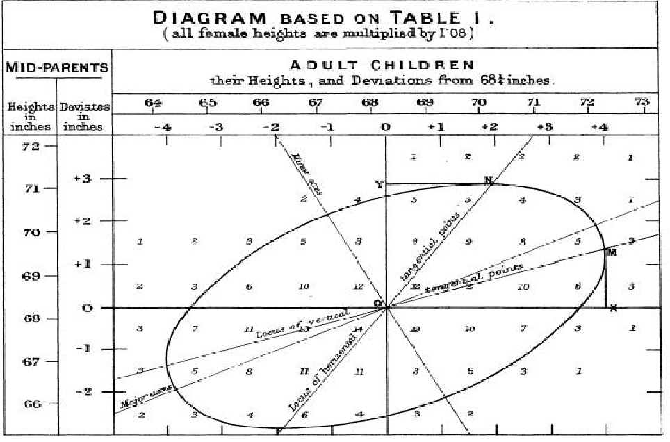

#### Your Data Visualization

**This plot uses the children dataset.**

Create a scatterplot of child height (x-axis) versus mid-parent height (y-axis). Ordinarily, we might reverse the axes here because analysts would be more likely to model child height as a function of parent height, but we want to be able to compare the updated plot to Galton’s original.

Include the following.

- make your dots larger than the default size to help show density
- set transparency to adjust for overplotting and help show density
- use `color =` in the `aes` to differentiate sons versus daughters
- use `scale_color_manual()` to choose two colorblind-safe colors
- scale both axes so that there is a tick mark at every whole inch
- use `coord_fixed()` so that the axes have the same unit spacing
- add better x- and y-axis labels, including the units of measure
- add an informative title (you may optionally include a subtitle)
- add `color =` to `labs()` to set the legend title to `"gender of child"`
- use a built-in theme (e.g., `theme_linedraw()`) to add formatting
- use `theme()` to move the legend to the bottom of the scatterplot

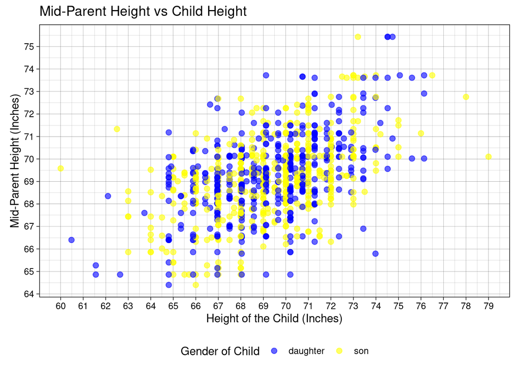

```r
ggplot(galtondata1, aes(x = child_ht, y = Midparent, color = child_sex)) +
       geom_point(size = 2.2, alpha = 0.6) +
        scale_color_manual(values = c("blue", "yellow")) +
        coord_fixed() +
        scale_x_continuous(breaks = seq(60, 80, 1)) +
        scale_y_continuous(breaks = seq(64, 75, 1)) +
        labs(title = "Mid-Parent Height vs Child Height",
        x = "Height of the Child (Inches)",
        y = "Mid-Parent Height (Inches)",
            color = "Gender of Child") +
        theme_linedraw() +
        theme(legend.position = "bottom")
```

### Visualization 2: “Transmuting” Effect

**These plots use the children dataset.**

#### The Raw Data

Use `histogram()` or `density()` to plot `child_ht_raw`. Use faceting so that there is a separate plot for sons and daughters, with one plot above the other (*not* side by side). If you use a histogram, change the default `bins = 30` to a reasonable value for the data. Choose appropriate colors, labels, themes, and/or and other types of formatting that you feel will enhance the meaning or visual appearance of the plot.

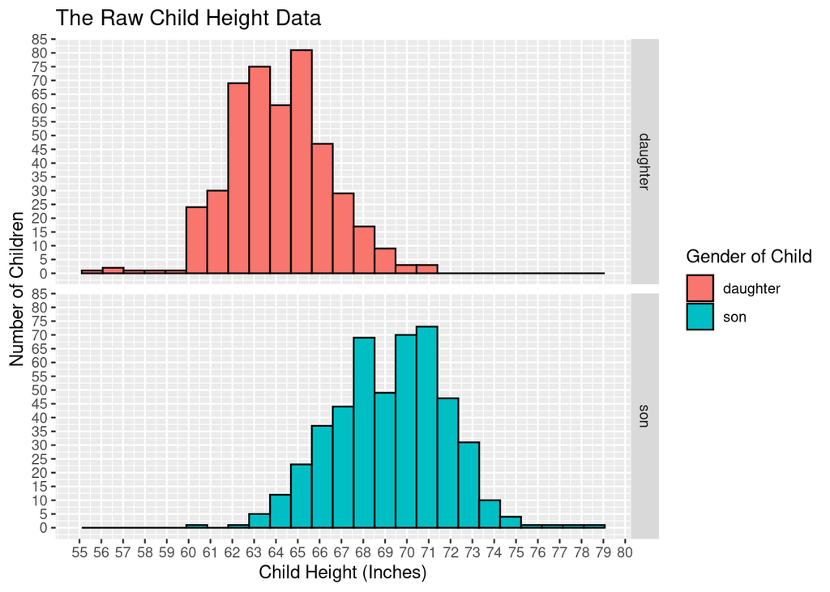

```r
ggplot(galtondata1, aes(child_ht_raw, fill = child_sex)) +
    geom_histogram(bins = 25, color = "black") +
    facet_grid(child_sex ~ .) +
    scale_x_continuous(breaks = seq(55, 80, 1)) +
    scale_y_continuous(breaks = seq(0, 85, 5)) +
    labs(title = "The Raw Child Height Data",
        x = "Child Height (Inches)",
        y = "Number of Children") +
scale_fill_discrete(name = "Gender of Child")
```

Use `group_by()` and `summarize()` to calculate the mean, standard deviation, minimum, median, and maximum of the measured heights for sons and daughters.

```r
galtondata1 %>%
 group_by(child_ht_raw) %>%
 summarize(average = mean(child_ht_raw, na.rm = TRUE),
           child_ht_standard_deviation = sd(galtondata1$child_ht_raw, na.rm = TRUE),
           child_ht_minimum = min(galtondata1$child_ht_raw, na.rm = TRUE),
           child_ht_median = median(galtondata1$child_ht_raw, na.rm = TRUE),
           child_ht_maximim = max(galtondata1$child_ht_raw, na.rm = TRUE)) %>%
 na.omit()
```

```
# A tibble: 66 × 6
   child_ht_raw average child_ht_standard_deviation child_ht_m…¹ child…² child…³
          <dbl>   <dbl>                       <dbl>        <dbl>   <dbl>   <dbl>
 1         56      56                          3.58           56    66.5      79
 2         57      57                          3.58           56    66.5      79
 3         57.5    57.5                        3.58           56    66.5      79
 4         58      58                          3.58           56    66.5      79
 5         59      59                          3.58           56    66.5      79
 6         60      60                          3.58           56    66.5      79
 7         60.1    60.1                        3.58           56    66.5      79
 8         60.5    60.5                        3.58           56    66.5      79
 9         61      61                          3.58           56    66.5      79
10         61.2    61.2                        3.58           56    66.5      79
# … with 56 more rows, and abbreviated variable names ¹child_ht_minimum,
#   ²child_ht_median, ³child_ht_maximim
```

#### The Transmuted Data

Create a similar plot as above, this time for `child_ht`. Be sure that the labels you use clearly distinguish between this plot and the previous one, especially if the other styling is very similar.

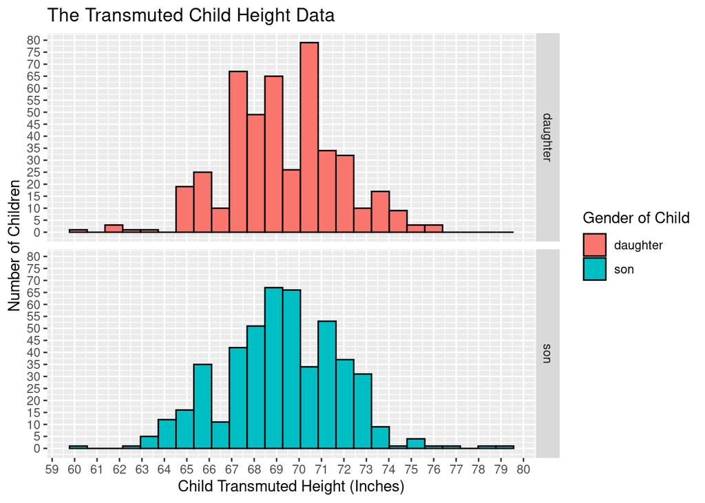

```r
ggplot(galtondata1, aes(child_ht, fill = child_sex)) +
    geom_histogram(bins = 25, color = "black") +
    facet_grid(child_sex ~ .) +
    scale_x_continuous(breaks = seq(55, 80, 1)) +
    scale_y_continuous(breaks = seq(0, 85, 5)) +
    labs(title = "The Transmuted Child Height Data",
        x = "Child Transmuted Height (Inches)",
        y = "Number of Children") +
scale_fill_discrete(name = "Gender of Child")
```

Use `group_by()` and `summarize()` to calculate the mean, standard deviation, minimum, median, and maximum of the transmuted heights for sons and daughters.

```r
galtondata1 %>%
 group_by(child_ht) %>%
 summarize(average = mean(child_ht, na.rm = TRUE),
           child_ht_standard_deviation = sd(galtondata1$child_ht, na.rm = TRUE),
           child_ht_minimum = min(galtondata1$child_ht, na.rm = TRUE),
           child_ht_median = median(galtondata1$child_ht, na.rm = TRUE),
           child_ht_maximim = max(galtondata1$child_ht, na.rm = TRUE)) %>%
 na.omit()
```

```
# A tibble: 88 × 6
   child_ht average child_ht_standard_deviation child_ht_minimum child…¹ child…²
      <dbl>   <dbl>                       <dbl>            <dbl>   <dbl>   <dbl>
 1     60      60                          2.58               60    69.1      79
 2     60.5    60.5                        2.58               60    69.1      79
 3     61.6    61.6                        2.58               60    69.1      79
 4     62.1    62.1                        2.58               60    69.1      79
 5     62.5    62.5                        2.58               60    69.1      79
 6     62.6    62.6                        2.58               60    69.1      79
 7     63      63                          2.58               60    69.1      79
 8     63.7    63.7                        2.58               60    69.1      79
 9     64      64                          2.58               60    69.1      79
10     64.5    64.5                        2.58               60    69.1      79
# … with 78 more rows, and abbreviated variable names ¹child_ht_median,
#   ²child_ht_maximim
```

### Visualization 3: Number of Children

**This plot uses the parents dataset.**

Create a barplot to show the distribution of the number of children per family. Set the bars to something other than the default `width`. Scale the x-axis so that there is a tick mark for each bar. Choose appropriate colors, labels, themes, and/or and other types of formatting that you feel will enhance the meaning or visual appearance of the plot. (Hint: Use `count()` to find out how many families have a given number of children, then use that smaller summary dataset to create your plot.)

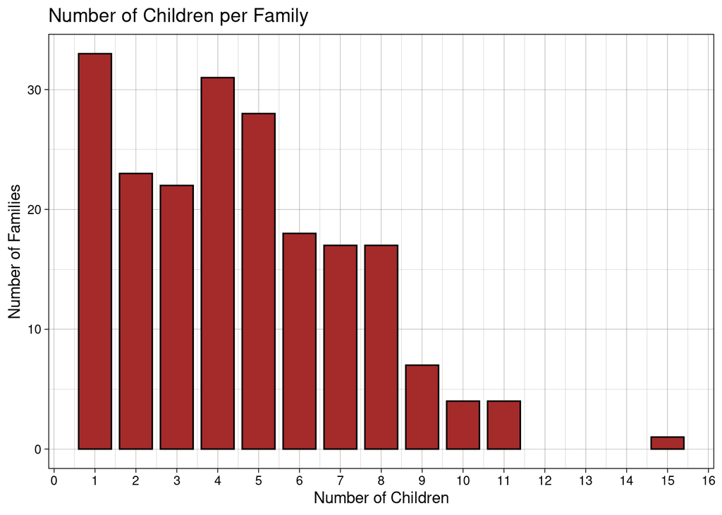

```r
parentdata %>%
  count(num_children) %>%
ggplot(aes(x = num_children, y = n)) +
    geom_col(width = 0.8, color = "black", fill = "brown") +
    scale_x_continuous(breaks = seq(0, 16, 1)) +
    labs(title = "Number of Children per Family",
        x = "Number of Children",
        y = "Number of Families") +
theme_linedraw()
```

## Questions

**Question 1:** Do you think your scatterplot is an improvement over Galton’s original diagram? Are there any other modifications and/or additions you would make to enhance the clarity or usefulness of your plot?

**ANSWER** We believe that our scatterplot is an improvement over Galton’s original diagram because it is easier to look at and read. We are able to tell from our scatterplot that the data has a positive correlation, which we weren’t able to tell from Galtons original diagram. The other modifications or additions we would make to enhance the clarity and usefulness of this plot would be playing around with better color combinations, displaying the data in other ways, or maybe even breaking up the scatterplot and using a faceted graph to look at the data.

**Question 2:** Did Galton’s “transmuting” of daughters’ heights succeed in making their data more similar to sons? How can you tell, based on your data visualizations and summaries?

**ANSWER** Some of the features not explicitly stated were to change dot size and transparency for visual one, without giving us an exact number to change them to. We decided to use the numbers we chose for these because once our plot was created, it made the plot more aesthetically pleasing to see. For visual two, we decided to use “scale_fill_discrete” to make our bar graphs filled with gender, making them appear pink for daughters and blue for sons. We also decided to use “theme_linedraw” for a few plots as well to enhance visualization of our plots.

**Question 4:** Considering best practices, how does using `coord_fixed()` enhance the authenticity of the information shown in the scatterplot, such as the relationship and spread of the data?

**ANSWER** Coord_fixed() was used in order to fix the ratio of length on both the x and the y axes. This allows both axes to have equal scales and it makes the entire plot more pleasing to the eye. Not only does it make it more pleasing to the eye but it also keeps the scale the same so that it doesn’t wrongly depict the plot by stretching it out. The relationship is displayed between the axes more which allows the viewer to understand the information easier and see how both variables are connected. Also, if the data is clumped close together, it has the ability to spread it out on the graph. And vice versa.